# Example trackdown doc

Lorem ipsum dolor sit amet, consectetur adipiscing elit. Sed dictum ipsum vel erat lobortis, et rhoncus sapien luctus.

# INTRODUCTION

Changes in intro., consectetur adipiscing elit. Sed dictum ipsum vel erat lobortis, et rhoncus sapien luctus. Aenean volutpat, tortor ac sodales malesuada, ex libero accumsan lectus, a pretium risus purus eu felis. Donec nec fringilla dolor. Pellentesque sagittis mi sit amet nibh sollicitudin, in commodo enim cursus. Proin ac dolor nunc. Mauris consectetur magna at ligula cursus facilisis. Fusce pulvinar lacus nec erat vestibulum, sed tincidunt arcu feugiat. Maecenas eget magna sed nunc molestie placerat id at ligula. Duis pharetra, ligula vel hendrerit tincidunt, orci dui elementum neque, eu efficitur sem turpis sed leo. Vestibulum volutpat augue tortor, eget vestibulum leo lacinia vel.

@fig-seals proin ac dolor nunc. Mauris consectetur magna at ligula cursus facilisis. Fusce pulvinar lacus nec erat vestibulum, sed tincidunt arcu feugiat. Maecenas eget magna sed nunc molestie placerat id at ligula. Duis pharetra, ligula vel hendrerit tincidunt, orci dui elementum neque, eu efficitur sem turpis sed leo. Vestibulum volutpat augue tortor, eget vestibulum leo lacinia vel.

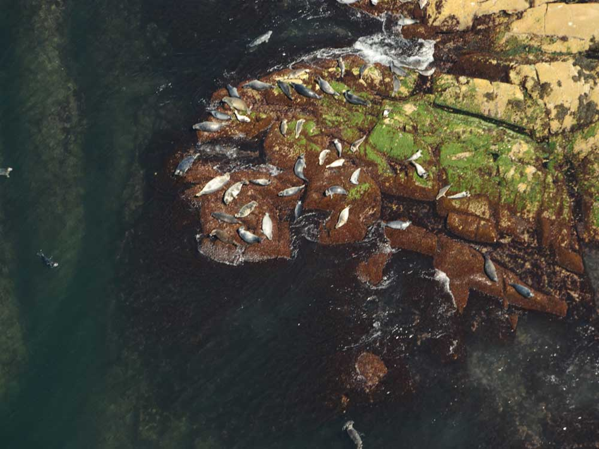

Duis pharetra, ligula vel hendrerit tincidunt, orci dui elementum neque, eu efficitur sem turpis sed leo. Vestibulum volutpat augue tortor, eget vestibulum leo lacinia vel.

## SAMPLING LOCATIONS

Lorem ipsum dolor sit amet, consectetur adipiscing elit. Sed dictum ipsum vel erat lobortis, et rhoncus sapien luctus. Aenean volutpat, tortor ac sodales malesuada, ex libero accumsan lectus, a pretium risus purus eu felis. Donec nec fringilla dolor. Pellentesque sagittis mi sit amet nibh sollicitudin, in commodo enim cursus. Proin ac dolor nunc. Mauris consectetur magna at ligula cursus facilisis. Fusce pulvinar lacus nec erat vestibulum, sed tincidunt arcu feugiat. Maecenas eget magna sed nunc molestie placerat id at ligula. Duis pharetra, ligula vel hendrerit tincidunt, orci dui elementum neque, eu efficitur sem turpis sed leo. Vestibulum volutpat augue tortor, eget vestibulum leo lacinia vel (@fig-plot).

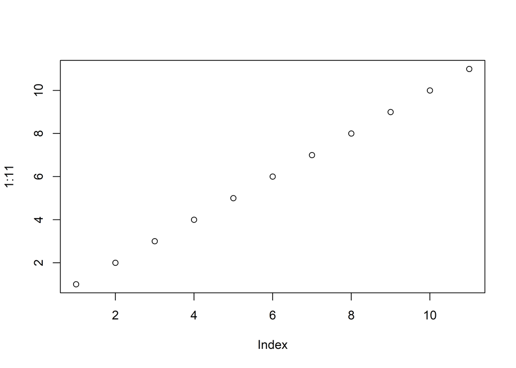

Duis pharetra, ligula vel hendrerit tincidunt, orci dui elementum neque, eu efficitur sem turpis sed leo. Vestibulum volutpat augue tortor, eget vestibulum leo lacinia vel.

## ANOTHER CHAPTER

Lorem ipsum dolor sit amet, consectetur adipiscing elit. Sed dictum ipsum vel erat lobortis, et rhoncus sapien luctus. Aenean volutpat, tortor ac sodales malesuada, ex libero accumsan lectus, a pretium risus purus eu felis. Donec nec fringilla dolor. Pellentesque sagittis mi sit amet nibh sollicitudin, in commodo enim cursus. Proin ac dolor nunc. Mauris consectetur magna at ligula cursus facilisis. Fusce pulvinar lacus nec erat vestibulum, sed tincidunt arcu feugiat. Maecenas eget magna sed nunc molestie placerat id at ligula. Duis pharetra, ligula vel hendrerit tincidunt, orci dui elementum neque, eu efficitur sem turpis sed leo. Vestibulum volutpat augue tortor, eget vestibulum leo lacinia vel.

# YET ANOTHER

*Lorem ipsum dolor sit amet*, consectetur adipiscing elit. Sed dictum ipsum vel erat lobortis, et rhoncus sapien luctus. Aenean volutpat, tortor ac sodales malesuada, ex libero accumsan lectus, a pretium risus purus eu felis. Donec nec fringilla dolor. Pellentesque sagittis mi sit amet nibh sollicitudin, in commodo enim cursus. Proin ac dolor nunc. Mauris consectetur magna at ligula cursus facilisis. Fusce pulvinar lacus nec erat vestibulum, sed tincidunt arcu feugiat. Maecenas eget magna sed nunc molestie placerat id at ligula. Duis pharetra, ligula vel hendrerit tincidunt, orci dui elementum neque, eu efficitur sem turpis sed leo. Vestibulum volutpat augue tortor, eget vestibulum leo lacinia vel.

## AND MORE

Lorem ipsum dolor sit amet, consectetur adipiscing elit. Sed dictum ipsum vel erat lobortis, et rhoncus sapien luctus. Aenean volutpat, tortor ac sodales malesuada, ex libero accumsan lectus, a pretium risus purus eu felis. Donec nec fringilla dolor. Pellentesque sagittis mi sit amet nibh sollicitudin, in commodo enim cursus. Proin ac dolor nunc. Mauris consectetur magna at ligula cursus facilisis. Fusce pulvinar lacus nec erat vestibulum, sed tincidunt arcu feugiat. Maecenas eget magna sed nunc molestie placerat id at ligula. Duis pharetra, ligula vel hendrerit tincidunt, orci dui elementum neque, eu efficitur sem turpis sed leo. Vestibulum volutpat augue tortor, eget vestibulum leo lacinia vel.

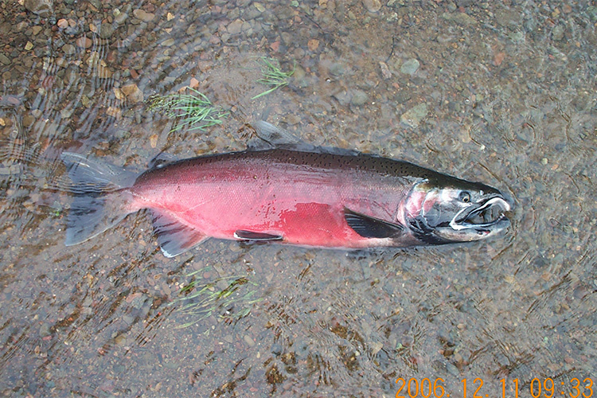

Duis pharetra, ligula vel hendrerit tincidunt, orci dui elementum neque, eu efficitur sem turpis sed leo. Vestibulum volutpat augue tortor, eget vestibulum leo lacinia vel.

Lorem ipsum dolor sit amet, consectetur adipiscing elit (@fig-coho). Sed dictum ipsum vel erat lobortis, et rhoncus sapien luctus. Aenean volutpat, tortor ac sodales malesuada, ex libero accumsan lectus, a pretium risus purus eu felis. Donec nec fringilla dolor. Pellentesque sagittis mi sit amet nibh sollicitudin, in commodo enim cursus. Proin ac dolor nunc. Mauris consectetur magna at ligula cursus facilisis. Fusce pulvinar lacus nec erat vestibulum, sed tincidunt arcu feugiat. Maecenas eget magna sed nunc molestie placerat id at ligula. Duis pharetra, ligula vel hendrerit tincidunt, orci dui elementum neque, eu efficitur sem turpis sed leo. Vestibulum volutpat augue tortor, eget vestibulum leo lacinia vel.

Proin volutpat elit suscipit, placerat ligula ac, rutrum erat. Maecenas nec elit eu purus tristique finibus. Pellentesque pretium nisi et ullamcorper ullamcorper. Class aptent taciti sociosqu ad litora torquent per conubia nostra, per inceptos himenaeos. Vestibulum in ligula in mi accumsan pellentesque at accumsan turpis. Nam lorem nisi, ultricies ut condimentum quis, pharetra nec metus. Cras eleifend auctor enim, ac faucibus sem facilisis vel.